# 2017-09-02-probability

> 02 Sep 2017 » probability, statistics

## 수식이 깨질 경우 새로고침을 눌러주세요.

## Probability for Data-Science ③

## 랜덤 변수 Random Variable

- 랜덤 변수는 샘플에 대한 **실수값**을 정의한 함수 $$ \omega \; \xrightarrow{X} \; \text{real value} $$

$$X(⚀) = 1$$$$X(⚁) = 2$$$$X(⚂) = 3$$$$X(⚃) = 4$$$$X(⚄) = 5$$$$X(⚅) = 6$$

- 특정 연속성 조건을 만족해야 한다.
  - 모든 Borel Set에 대한 inverse event가 sigma field에 속해야 한다.

### 랜덤 변수와 확률

> 랜덤 변수의 이벤트를 실수 구간으로 바꾸어 정의할 수 있다.
> - event measure → interval measure $$P(\{ a \leq X < b \}) = P(\{ \omega ; a \leq X(\omega) < b \}) $$
- 확률 분포 함수(PDF, Probability Distribution Function)

$$\mu[a,b) = P(\{ a \leq X < b \})$$

> **확률 분포 함수** 구간은 2차원이므로 사용하기가 어렵다.

> **누적 확률 분포 함수(cdf)** → 표만들기 좋음

> **확률 밀도 함수(pdf)**

> > cdf를 미분하여 구함.

> > 구간별 확률 보기가 좋다.

### 누적 확률 분포 함수 Cumulative Distribution Function

> 전체 이벤트(구간)가 아니라 일부 이벤트(구간)에 대해서만 확률을 정의한다.

> > 나머지 이벤트는 확률 공리와 확률 정리에서 도출할 수 있다.

> 이벤트 나열 규칙

> > $$ (-\infty, \;\text{a}) $$

> > 시작점을 -무한대로 고정하고 계산한다.

$$P( \{ -\infty \leq X < -1 \}) $$$$P( \{ -\infty \leq X < -2 \}) $$$$P( \{ -\infty \leq X < 0 \}) $$$$P( \{ -\infty \leq X < 1 \}) $$$$P( \{ -\infty \leq X < 2 \}) $$$$ \vdots \\ $$$$P( \{ -\infty \leq X < x \}) \\$$$$ \downarrow $$$$ \bbox[7px, border:2px solid red]{F(X=x) = P( \{ -\infty \leq X < x \})} $$$$ ∴ \;\; F(X=-\infty) = 0, \;\; F(X=\infty) = 1 $$

#### Ex) 시계 바늘의 확률

> 시계 바늘 각도 $\theta$가 0도에서 360까지 균일하게 나타난다. 누적 확률 분포: 시계 바늘 각도가 0도에서 X도까지의 구간에 있을 확률
> > - $F(X) = \{0 \leq θ < X\}$
> > - $X$가 증가함에 따라 구간 확률은 균일하게 증가한다.
> > - $X=0$일 때 구간 확률은 $0$
> > - $X=360$일 때 구간 확률은 $1$

```python
import numpy as np
import matplotlib as mpl
import matplotlib.pylab as plt
%matplotlib inline
```

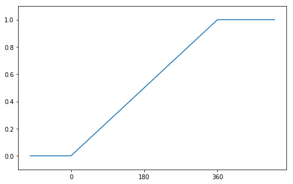

```python
# 캔버스의 크기
plt.figure(figsize=(8,5))

# (시작, 끝, 1000개의 점을 찍어서 연결해라.)
t = np.linspace(-100, 500, 1000)

# CDF
F = t / 360
F[t < 0] = 0
F[t > 360] = 1

# F(t)를 그려라.
plt.plot(t, F)

# x, y축의 범위 설정
plt.ylim(-0.1, 1.1)
plt.xticks([0, 180, 360]); ## 세미콜론을 붙이면, 기타요소가 출력되지 않는다.
```

### 확률 밀도 함수 Probability Density Function

- 누적 확률 분포 함수의 미분으로 정의

$$ \int_a^b f(x) dx = F(X=x) = P( \{ a \leq X < b \}) $$$$ \dfrac{dF(x)}{dx} = f(x) $$

- 특정 구간이 다른 구간에 비해 얼마나 확률이 높은가를 나타내는 **상대적인** 값

> 누적 확률 분포 함수 $$F(x)$$

> 확률 밀도 함수 $$F^{'}(x) = f(x)$$

#### Ex) 시계 바늘의 확률

$$0 \leq x \leq 360$$$$f(x) = \frac{dF(x)}{dx}$$

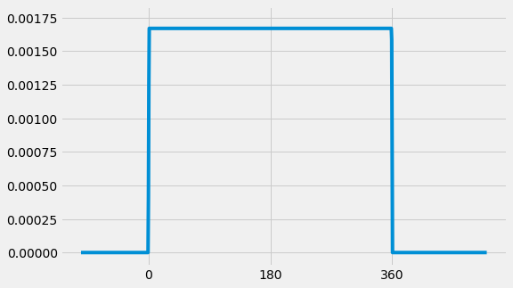

```python
# 스타일 주기
with plt.style.context('fivethirtyeight'):
    # 캔버스의 크기
    plt.figure(figsize=(8,5))

    ## F(t) 미분
    f = np.gradient(F)

    # f(t)를 그려라.
    plt.plot(t, f)

    # y축은 -0.0001 부터 최대값의 1.1배까지 그려라.
    plt.ylim(-0.0001, f.max()*1.1)

    # x축위에 다음 점을 찍어라.
    plt.xticks([0, 180, 360]);
```

### 기대값 Expectation

> 랜덤 변수의 기대값은 랜덤 변수의 Lebesque 적분 $$ E[X] = \int_\Omega X(\omega) d \bbox[5px, border:1px solid red]{P(\omega)} $$

> 확률로 가중치를 주어 기대값을 구함

> pdf **f(x)**가 정의되어 있으면 Riemann 적분으로 계산 가능 → 흔히 배운 적분 $$ E[X] = \int_{x=-\infty}^{\infty} x\cdot f(x)dx $$

$$ E[X] = \sum x \cdot f(x) $$

> 랜덤 변수의 함수 **g(X)**도 랜덤 변수이므로 기대값 계산 가능 ← **first moment 적률**

$$ E[g(X)] = \int_{x=-\infty}^{\infty} g(x)f(x)dx $$$$ E[g(X)] = \sum g(x) \cdot f(x) $$

### 기대값의 성질

- 고정값 랜덤 변수가 아닌 고정된 값 $c$에 대해 $$ \operatorname{E}[c] = c$$
- 선형성(linearity) $$ \begin{align} \operatorname{E}[X + c] &= \operatorname{E}[X] + c \\ \operatorname{E}[cX] &= c \operatorname{E}[X] \\ \operatorname{E}[X + Y] &= \operatorname{E}[X] + \operatorname{E}[Y] \end{align} $$

### 대표값

> **평균 mean** $$ \mu = E[X] = \int_{x=-\infty}^{\infty} xf(x)dx$$

$$ \mu = E[X] = \sum x \cdot f(x) $$

> **중간값(미디언) median** $$ \text{median} = F^{-1}(0.5) $$

$$ 0.5 = F(median) $$

> **최빈값(모드) mode** $$ \text{mode} = \arg \max f(x) $$

> > 여기서는 최대값이 된다.

> **분산 variance $\sigma^2$** $$ \sigma^2 =\text{Var}[X] = E[(X - \mu)^2] = \int_{x=-\infty}^{\infty} (x - \mu)^2 f(x)dx$$

$$ \sigma^2 = \text{Var}[X] = E[(X - \mu)^2] = \sum (x - \mu)^2 f(x)$$

> **표준편차 standard deviation($\sigma$)** $$\sigma = \sqrt{\sigma^2}$$

> **precision($\beta$)** $$\beta = \dfrac{1}{\sigma^2}$$

> **왜도 skewness**

> > 분포가 어느 한쪽으로 치우쳤는지 확인

> > **왜도의 값이 +값이면 왼쪽**으로 치우친다. (- 값을 갖으면 그 반대)

$$ \frac{\mu_3}{\sigma^3} = \operatorname{E}\left[\left(\frac{X-\mu}{\sigma}\right)^3 \right] $$

[figure not shown]

> **첨도 kurtosis**

> > 뭉툭한지 뾰족한지 체크

> > **값이 클수록 뾰족하다.** $$ \frac{\mu_4}{\sigma^4} = \frac{\operatorname{E}[(X-{\mu})^4]}{(\operatorname{E}[(X-{\mu})^2])^2} $$

[figure not shown]

$$\hat{x}$$

### Moment(적률)

$$ E[(X-\mu)^n] $$

> 1st moment $$E[X]$$ 2nd moment $$[(X-\mu)^2]$$ 3rd moment $$[(X-\mu)^3]$$

## Variance의 성질

$$ \text{Var}[X] = E[X^2] - (E[X])^2 = E[X^2] - \mu^2$$

> **pf)** $$ \begin{eqnarray*} \text{Var}[X] &=& E[(X-\mu)^2] \\ &=& E(X^2 -2\mu X +\mu^2) \\ &=& E(X^2) -2\mu E(X) + E(\mu^2) \\ &=& E(X^2) -2\mu^2 + \mu^2 \\ &=& E(X^2) - \mu^2 \\ \end{eqnarray*} $$

### Sample Mean

- sample mean도 변형된 Random variable
- $X_i$ 는 같은 분포에서 $i$번째로 뽑은 숫자

$$ \hat{X} = \dfrac{1}{N} \sum_{i=1}^N X_i\\ $$

양변에 기대값 E( )를 취하면

$$ E[\hat{X}] = \dfrac{1}{N} \sum_{i=1}^N E[X_i] = \dfrac{1}{N} \sum_{i=1}^N \mu = \mu$$

## 확률 모형 Probability Model

> 현실에서 자주 나타나는 몇 가지 확률 밀도 함수를 미리 정의해 놓은 것

### 확률 모형의 이용

> 분석하고자 하는 데이터를 랜덤 변수의 샘플이라고 가정한다

> 그 랜덤 변수를 잘 표현할 것 같은 확률 모형을 찾는다
> > 1. 원리를 생각하고 찾는다.
> > 2. 데이터 분포의 모양을 보고 찾는다.

### 단일 변수 확률모형

> **이산 확률 모형**
> - Bernoulli
> - Binomial

> **연속 확률 모형**
> - Gaussian normal
> - Beta
> - Gamma
> - student-t
> - chi-square
> - F

### Bernoulli distribution 베르누이 분포

> 베르누이 시도(동전 던지기 1회)
> - 성공(1) / 실패(0)
> - 동전의 앞면(Head) / 뒷면(Tail)

> 베르누이 시도에서 1이 나올 확률이 $\theta$이면

$$ \begin{eqnarray*} \text{Bern}(x;\theta) &=& \begin{cases} \theta & \text{if}(x=1), \\ 1-\theta & \text{if}(x=0) \end{cases} \\ \\ &=& \theta^x(1-\theta)^{(1-x)}, \;\; (x=0, 1) \end{eqnarray*} $$

> 만약 베르누이 확률 변수(X)가 1과 -1이라는 값을 가진다면 다음과 같은 수식으로 써야 한다. $$\text{Bern}(x;\theta) \;=\; \theta^{\frac{(1+x)}{2}}(1−\theta)^{\frac{(1−x)}{2}}, \;\; (x=-1, 1)$$

> fair coin인 경우에는 $\theta=0.5$

> Mean: $$E[x] = 1 \cdot \theta + 0 \cdot (1 - \theta) = \theta$$

> Variance: $$\text{Var}[x] = (1 - \theta)^2 \cdot \theta + (0 - \theta)^2 \cdot (1 - \theta) = \theta(1-\theta)$$

| 분포 | pmf(확률질량함수) | 평균 | 분산(Variance) |
| --- | --- | --- | --- |
| Bernoulli distribution | $$\begin{eqnarray*}f(x;\theta) = \theta^{x}(1-\theta)^{1-x}\end{eqnarray*}, \;\; (x=0, 1)$$ | $$\theta$$ | $$\theta(1-\theta)$$ |

$$X∼Bern(x;\theta)$$

### Sympy로 분포를 확인해보자.

[Sympy Document](http://docs.sympy.org/latest/modules/stats.html)

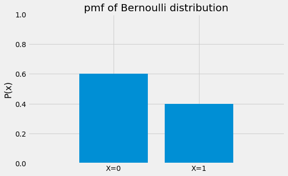

```python
# -*- coding: utf-8 -*-

import sympy
from sympy.stats import *

# x 정의
x = [0,1]

# pmf(확률질량함수) 정의
D = sympy.stats.Bernoulli('x', 0.6)
f = density(D).dict

# 스타일
with plt.style.context('fivethirtyeight'):
    plt.figure(figsize=(8,5))

    ## dict를 막대그래프로 시각화
    plt.bar(range(len(f)), f.values(), align="center")

    ## 축 범위 지정
    plt.xlim(-1, 2)
    plt.ylim(0, 1)

    ## x축위에 다음 점을 찍고, Labeling
    plt.xticks([0, 1], ["X=0", "X=1"])

    ## y축 라벨링
    plt.ylabel("P(x)")

    ## 타이틀
    plt.title("pmf of Bernoulli distribution")
    plt.show()
```

### 시뮬레이션

```python
import seaborn as sns
import pandas as pd
```

```python
# sympy.stats의 sample 메소드로 100개를 샘플링하
simul = []
for i in range(100):
    sample(D)
    s = sample(D)
    simul.append(s)

simulation = np.array(simul)
simulation = simulation.astype('int64')
simulation
```

```
array([0, 0, 1, 1, 1, 1, 0, 1, 1, 0, 1, 0, 1, 1, 1, 1, 0, 0, 0, 0, 0, 1, 1,
       1, 1, 0, 1, 1, 1, 1, 0, 1, 1, 0, 1, 1, 1, 0, 1, 0, 0, 1, 0, 1, 1, 1,
       1, 0, 0, 1, 0, 1, 1, 0, 0, 1, 0, 1, 1, 0, 1, 0, 0, 0, 0, 1, 1, 1, 1,
       1, 1, 1, 1, 0, 1, 1, 0, 0, 1, 0, 1, 1, 1, 0, 1, 1, 1, 1, 1, 0, 0, 1,
       1, 0, 0, 0, 1, 1, 1, 1])
```

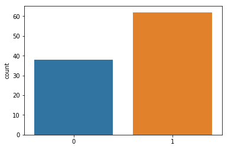

```python
sns.countplot(simulation)
plt.show()
```

```python
## minlength → x값 몇개?
y = np.bincount(simulation, minlength=2) / float(len(simulation))
y
```

```
array([ 0.38,  0.62])
```

```python
# y를 df로
df_simulation = pd.DataFrame({"simulation": y})

# dict 차원이 1인경우 시리즈로 변경후 판다스씌울 것
df_theory = pd.DataFrame(pd.Series(f, name='Theory'), dtype='float64')

df = pd.concat([df_theory, df_simulation], axis=1)
df
```

|  | Theory | simulation |
| --- | --- | --- |
| 0 | 0.4 | 0.38 |
| 1 | 0.6 | 0.62 |

```python
# df의 값을 알래로 쌓음
df2 = df.stack().reset_index()
df2.columns = ["value", "type", "ratio"]
df2
```

|  | value | type | ratio |
| --- | --- | --- | --- |
| 0 | 0 | Theory | 0.40 |
| 1 | 0 | simulation | 0.38 |
| 2 | 1 | Theory | 0.60 |
| 3 | 1 | simulation | 0.62 |

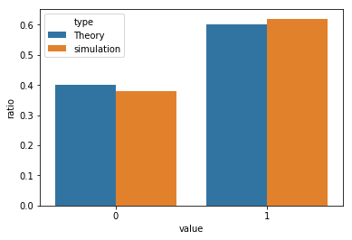

```python
sns.barplot(x="value", y="ratio", hue="type", data=df2)
plt.show()
```

- 위처럼 이론적인 값과 시뮬레이션한 값을 비교할 수 있다.

#### 위 시뮬레이션에서의 샘플 평균 및 샘플 분산은 다음과 같이 계산할 수 있다.

```python
np.float(np.mean(simulation))
```

```
0.62
```

```python
np.float(np.var(simulation, ddof=1))
```

```
0.23797979797979804
```

```python
import scipy
s = scipy.stats.describe(simulation)
s
```

```
DescribeResult(nobs=100, minmax=(0, 1), mean=0.62, variance=0.23797979797979804, skewness=-0.4944513860581974, kurtosis=-1.755517826825128)
```

```python
pd.Series(simulation).describe()
```

```
count    100.000000
mean       0.620000
std        0.487832
min        0.000000
25%        0.000000
50%        1.000000
75%        1.000000
max        1.000000
dtype: float64
```

> Share this on → [Tweet](https://twitter.com/share)

#### Related Posts

> « Python basic (function 함수) probability for data-science ④ »